# Homework 1 – QTM 151

Adam Shah

## Instructions:

**Due:** 02/15 at 11:59PM.

**What am I expecting?** An R Markdown and the compiled HTML with the answers.

**Have fun!**

## Homework 1

Use `qplot()` function to create plots about `diamonds`. The data set diamonds is built in the package `ggplot2`.

To get started:

```r
library(tidyverse)
data(diamonds)
```

**1**. Make a small random subset of diamonds and name it as `dsmall`.

```r
dsmall<- diamonds %>% sample_n(1000)
```

**2**. Show the distribution of carat with a histogram, set binwidth to 0.1 and limits for the x-axis from 0 to 3.

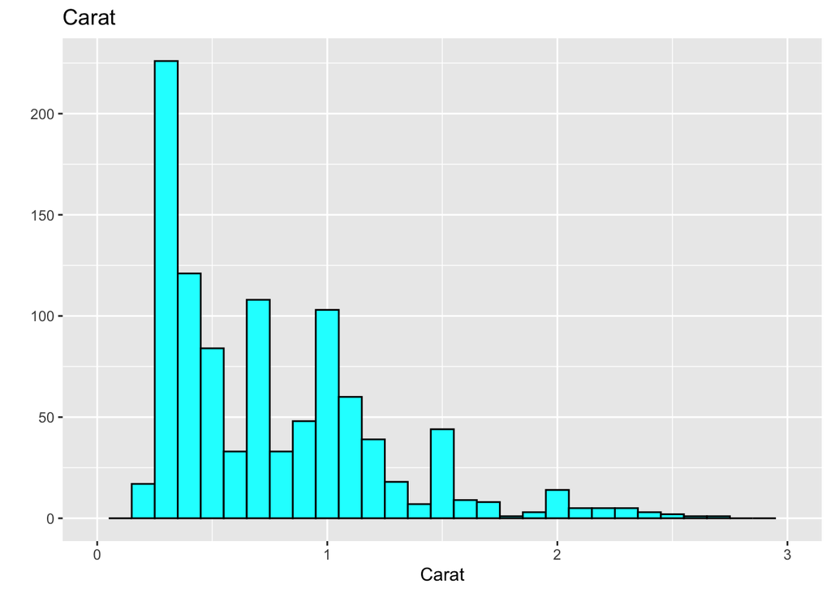

```r
qplot(dsmall$carat, geom= 'histogram',
      binwidth=0.1, main= 'Carat', xlab= 'Carat',
      fill= I('cyan'),color=I('black'), xlim=c(0,3))
```

**3**. Show the distribution of carat with a *density plot*, set the color to the variable `color`.

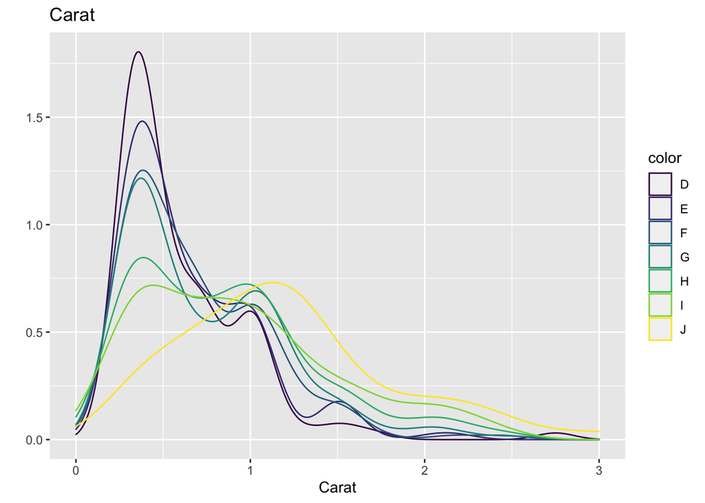

```r
qplot(carat, data= dsmall, geom= 'density',
      main= 'Carat', xlab= 'Carat',
      color=color, xlim=c(0,3))
```

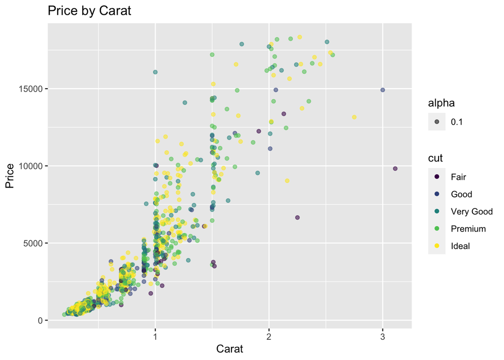

```r
qplot(carat, price, geom="point", data=dsmall,
      main='Price by Carat', xlab='Carat', ylab='Price',
      color=cut, alpha=0.1)
```

The trend of the scatter plot is that diamonds of a higher carat tend to be more expensive.

**5**. Make another scatter-plot between *carat* and *price*, add jitters to points, set point transparency to 0.1, apply log transformation to the x and y axes variables, and add a smooth line to the plot, then describe the trend of the scatter-plot.

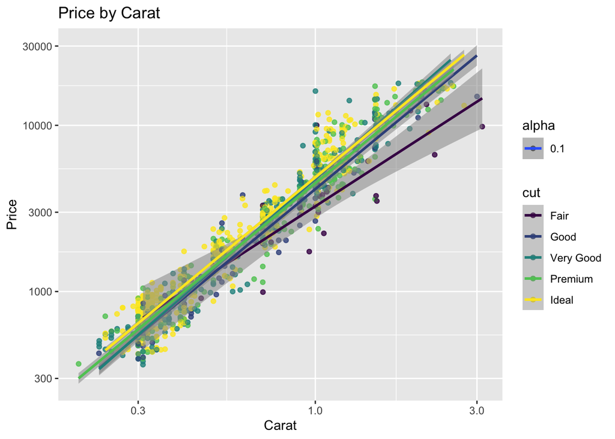

```r
qplot(carat, price, geom="point", data=dsmall,
      main='Price by Carat', xlab='Carat', ylab='Price',
      color=cut, alpha=0.1) + scale_x_log10() + scale_y_log10() + geom_jitter() + geom_smooth(method='lm')
```

The trend is that there is a positive linear relationship between the log of price and carat variables.